# Machine Learning Final Project

Christian Suarez

29/4/2020

# Summary

The goal of this project is to create a model for predicting if barbel lifts were correctly done, through variable ‘classe’ in our data set. Barbet lifts were done in 5 different ways by 6 persons, to model this we are going to use data from http://web.archive.org/web/20161224072740/http:/groupware.les.inf.puc-rio.br/har

```r
## Load data
setwd("C:/Users/CHRISTIAN/Desktop/Coursera/Specialization/2/ML/FinalProject")
data<-read.csv('pml-training.csv',na.strings = c("NA","#DIV/0!"))


## 20 observation from excercis as validation data set
validate<-read.csv('pml-testing.csv',na.strings = c("NA","#DIV/0!"))
dim(data)
```

```
## [1] 19622   160
```

# Prepare data and select variables

## Split Data

Split into train and test data sets using a proportion of 70%.

```r
temp <- createDataPartition(data$classe, p = 0.7, list=FALSE)
train<-data[temp,]
test<-data[-temp,]
```

## Analize NAs

This is necessary because a variable with a lot of NAs will be not usefull in our model. First, we are going to eliminate variables with more than 50% of NAs.

```r
remove<-!colSums(is.na(train))>nrow(train)/2
train<-train[,remove]
test<-test[,remove]
validate<-validate[,remove]
sum(complete.cases(train))/nrow(train)
```

```
## [1] 1
```

## Eliminate variables with low variability

```r
nearZeroVar(train, names = TRUE)
```

```
## [1] "new_window"
```

```r
table(data$new_window)
```

```
##
##    no   yes
## 19216   406
```

As wee can see variable ‘new_window’ has a very low variability because almost all its observations belongs to one class, so we are going to exclude it.

```r
train<-train[,-6]
test<-test[,-6]
validate<-validate[,-6]
```

## Check if classes are balanced

This is an important step because depending on this we must select the best accuracy meassure or we will need to balance the training data set.

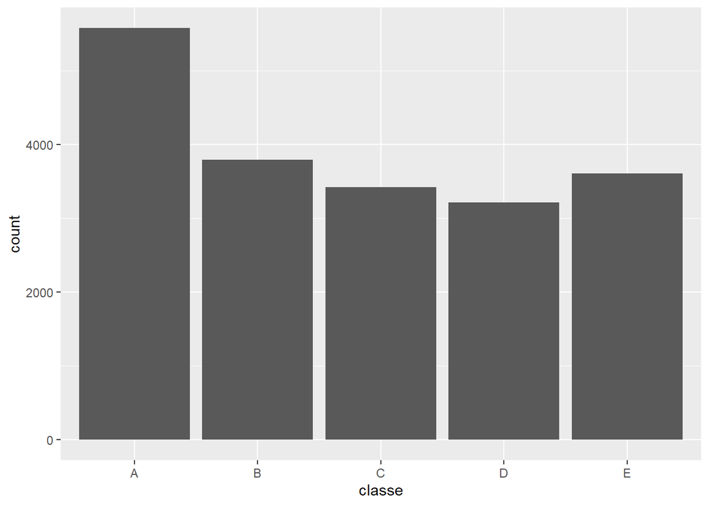

```r
ggplot(data, aes(classe)) + geom_bar()
```

```r
metric <- "Accuracy"
```

# Define model

We are looking for a model that can predict if any person in any moment is doing correctly barbel lifts, so we are going to exclude user and time variables.

```r
train<-train[,-c(1:5)]
test<-test[,-c(1:5)]
validate<-validate[,-c(1:5)]
```

## Analize correlation

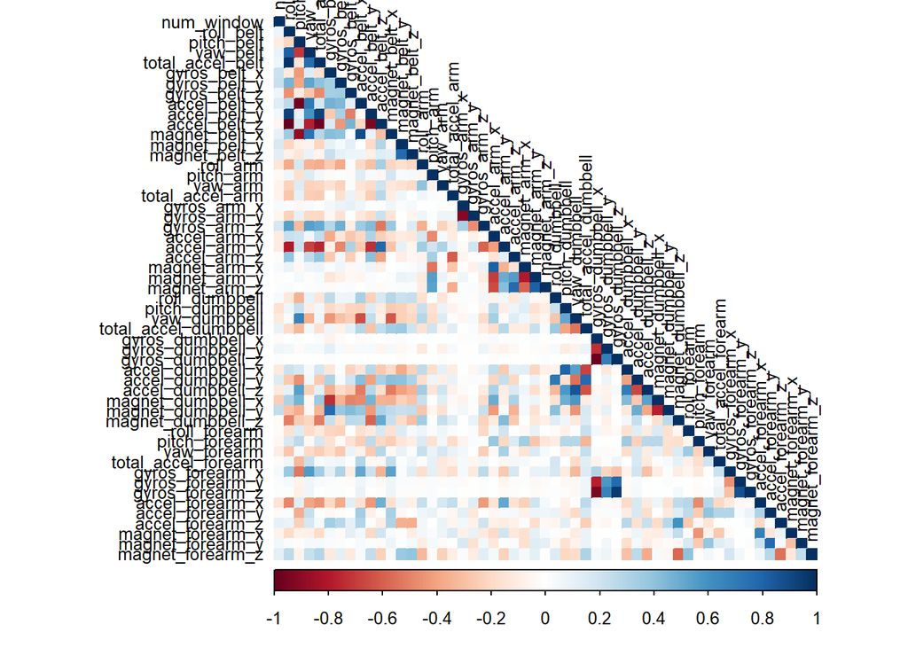

```r
correlation <- cor(train[, -54])
corrplot(correlation, method = "color", type = "lower",
         tl.cex = 0.8, tl.col = 'black')
```

Due to the logical correlation between diferent meassures of the same kind of data, it is neccesary to apply PCA to find the best combination of predictors, taking into account that in this case we are not looking for interpretability but accuracy

## Apply PCA

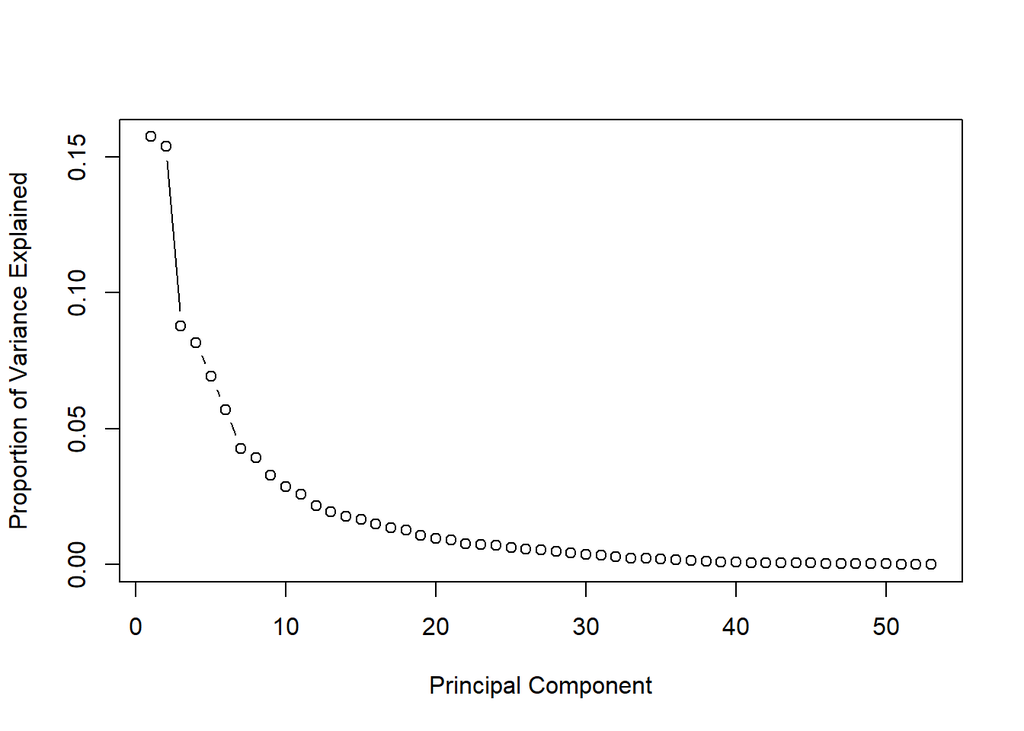

```r
pca <- prcomp(train[,-54], scale. = T)
variance<-pca$sdev^2
proportion<-variance/sum(variance)
plot(proportion, xlab = "Principal Component",
     ylab = "Proportion of Variance Explained",
     type = "b")
```

```r
sum(variance[1:24])/sum(variance)
```

```
## [1] 0.9444498
```

```r
pcatrain<-data.frame(classe = train$classe,pca$x)
pcatrain<-pcatrain[,1:25]
```

## Model with Random Forest

### Tuning

We are going to apply cross validation to avoid over fitting and try to optimize mtry hyperparameter and the number of trees.

```r
control <- trainControl(method="repeatedcv", number=3, repeats=2, search="grid")
tunegrid <- expand.grid(.mtry=c(1:3))
rf_gridsearch <- train(classe~., data=pcatrain, method="rf",
                       metric=metric, tuneGrid=tunegrid, trControl=control,ntree=300)
print(rf_gridsearch)
```

```
## Random Forest
##
## 13737 samples
##    24 predictor
##     5 classes: 'A', 'B', 'C', 'D', 'E'
##
## No pre-processing
## Resampling: Cross-Validated (3 fold, repeated 2 times)
## Summary of sample sizes: 9157, 9158, 9159, 9159, 9157, 9158, ...
## Resampling results across tuning parameters:
##
##   mtry  Accuracy   Kappa
##   1     0.9618186  0.9516959
##   2     0.9625829  0.9526634
##   3     0.9633109  0.9535849
##
## Accuracy was used to select the optimal model using the largest value.
## The final value used for the model was mtry = 3.
```

We can see that there is no significant increasse in accuracy by increassing the value of mtry, so we will check what happen when we increasse the number of trees.

```r
control <- trainControl(method="repeatedcv", number=3, repeats=2, search="grid")
tunegrid <- expand.grid(.mtry=1)
rf_gridsearch1 <- train(classe~., data=pcatrain, method="rf",
                       metric=metric, tuneGrid=tunegrid, trControl=control,ntree=1500)
print(rf_gridsearch1)
```

```
## Random Forest
##
## 13737 samples
##    24 predictor
##     5 classes: 'A', 'B', 'C', 'D', 'E'
##
## No pre-processing
## Resampling: Cross-Validated (3 fold, repeated 2 times)
## Summary of sample sizes: 9158, 9159, 9157, 9158, 9158, 9158, ...
## Resampling results:
##
##   Accuracy   Kappa
##   0.9643301  0.9548755
##
## Tuning parameter 'mtry' was held constant at a value of 1
```

We can see, the accuracy is similar to the model with 300 trees, so we are going to work with the first one bacause It is faster.

```r
fit<-rf_gridsearch$finalModel
fit
```

```
##
## Call:
##  randomForest(x = x, y = y, ntree = 300, mtry = param$mtry)
##                Type of random forest: classification
##                      Number of trees: 300
## No. of variables tried at each split: 3
##
##         OOB estimate of  error rate: 2.42%
## Confusion matrix:
##      A    B    C    D    E class.error
## A 3877   11   13    3    2 0.007424475
## B   48 2557   45    3    5 0.037998495
## C    2   29 2338   23    4 0.024207012
## D    2    6  101 2139    4 0.050177620
## E    2    1   10   18 2494 0.012277228
```

We can see that out of the bag error is low, so probably the model is not overfitted and will keep high accuracy with test data, so now we are going to check it.

```r
pcatest<-predict(pca,newdata = test[,-54])
pcatest<-data.frame(classe = test$classe,pcatest)
pcatest<-pcatest[,1:25]
prediction<-predict(fit,pcatest[,-1],type = 'response')
confusionMatrix(prediction,pcatest$classe)
```

```
## Confusion Matrix and Statistics
##
##           Reference
## Prediction    A    B    C    D    E
##          A 1659   20    2    1    0
##          B    5 1093   14    2    3
##          C    8   24  996   36    4
##          D    1    0   14  924   11
##          E    1    2    0    1 1064
##
## Overall Statistics
##
##                Accuracy : 0.9747
##                  95% CI : (0.9703, 0.9785)
##     No Information Rate : 0.2845
##     P-Value [Acc > NIR] : < 2.2e-16
##
##                   Kappa : 0.968
##
##  Mcnemar's Test P-Value : 1.414e-05
##
## Statistics by Class:
##
##                      Class: A Class: B Class: C Class: D Class: E
## Sensitivity            0.9910   0.9596   0.9708   0.9585   0.9834
## Specificity            0.9945   0.9949   0.9852   0.9947   0.9992
## Pos Pred Value         0.9863   0.9785   0.9326   0.9726   0.9963
## Neg Pred Value         0.9964   0.9904   0.9938   0.9919   0.9963
## Prevalence             0.2845   0.1935   0.1743   0.1638   0.1839
## Detection Rate         0.2819   0.1857   0.1692   0.1570   0.1808
## Detection Prevalence   0.2858   0.1898   0.1815   0.1614   0.1815
## Balanced Accuracy      0.9928   0.9773   0.9780   0.9766   0.9913
```

As we expect the model has a good performance in testing data, so this is our final model.

## Predicting the 20 given observations.

```r
pcavalidate<-predict(pca,newdata = validate[,-54])
pcavalidate<-data.frame(id= validate$problem_id,pcavalidate)
pcavalidate<-pcavalidate[,1:25]
prediction<-predict(fit,pcavalidate[,-1],type = 'response')
answers<-data.frame(ID= pcavalidate$id,prediction = prediction)
answers
```

```
##    ID prediction
## 1   1          B
## 2   2          A
## 3   3          B
## 4   4          A
## 5   5          A
## 6   6          E
## 7   7          D
## 8   8          B
## 9   9          A
## 10 10          A
## 11 11          B
## 12 12          C
## 13 13          B
## 14 14          A
## 15 15          E
## 16 16          E
## 17 17          A
## 18 18          B
## 19 19          B
## 20 20          B
```